# Homework 3 – QTM 150

Minh-Thy Tyler

## Instructions:

**Due:** 03/09 at 11:59PM.

**What am I expecting?** An R Markdown and the compiled HTML with the answers.

**Have fun!**

## Homework 3

**1** (1 pt). Import the dataset `LifetimeBoxOffice.csv` and answer: how many observations and variables are included in this file?

Hint: start by loading the data. There are two methods:

1. From GitHub
2. From a locale folder.

To use the first method, you have to go to our GitHub page, and load the file as raw. Our GitHub page is here: https://github.com/umbertomig/qtm150

To use the second method, you need to download the file and put in the same folder as this RMarkdown.

```r
getwd()
```

```
## [1] "/Users/minh-thytyler/Desktop/2021 freshman/QTM 150"
```

```r
dat <- read.csv('LifetimeBoxOffice.csv')
dim(dat)
```

```
## [1] 200   4
```

```r
# 200 observations, 4 variables
```

**2** (1 pt). Which movies are ranked in top 10 in terms of LifetimeGross? Print only the name of the movies and LifetimeGross for each movie. (Hint: the dataset is already order by LifetimeGross.)

```r
head(dat$Movie, 10)
```

```
##  [1] "Avengers: Endgame"
##  [2] "Avatar"
##  [3] "Titanic"
##  [4] "Star Wars: Episode VII - The Force Awakens"
##  [5] "Avengers: Infinity War"
##  [6] "Jurassic World"
##  [7] "The Lion King"
##  [8] "The Avengers"
##  [9] "Furious 7"
## [10] "Frozen II"
```

```r
head(dat$LifetimeGross, 10)
```

```
##  [1] 2797800564 2790439000 2194439542 2068223624 2048359754 1670400637
##  [7] 1656943394 1518812988 1515047671 1438869773
```

```r
# 1. Avengers: Endgame 2797800564 2. Avatar 2790439000 3. Titanic 2194439542 4. Star Wars: Episode VII - The Force Awakens 2068223624 5. Avengers: Infinity War 2048359754 6. Jurassic World 1670400637 7. The Lion King 1656943394 8. The Avengers 1518812988 9. Furious 7 1515047671 10. Frozen II 1438869773
```

**3** (2 pt). Print the movies (observations) that earned over a total of one billion dollars of LifetimeGross. (Hint: to select a subset of the data, try `help(subset)`, and see how the function subset works…)

```r
subset(dat, LifetimeGross > 1000000000, select = c(Movie, LifetimeGross) )
```

```
##                                            Movie LifetimeGross
## 1                              Avengers: Endgame    2797800564
## 2                                         Avatar    2790439000
## 3                                        Titanic    2194439542
## 4     Star Wars: Episode VII - The Force Awakens    2068223624
## 5                         Avengers: Infinity War    2048359754
## 6                                 Jurassic World    1670400637
## 7                                  The Lion King    1656943394
## 8                                   The Avengers    1518812988
## 9                                      Furious 7    1515047671
## 10                                     Frozen II    1438869773
## 11                       Avengers: Age of Ultron    1402805868
## 12                                 Black Panther    1346913161
## 13  Harry Potter and the Deathly Hallows: Part 2    1341932398
## 14       Star Wars: Episode VIII - The Last Jedi    1332539889
```

[output cut: 32 more lines]

```r
# your answers here
```

**4** (2 pt). Which movies released in 2019 made this list of top 200 movies? Create a subset of LBO containing only the movies released in 2019. (Hint: again, try `help(subset)`, and see how the function works. Also, one equal sign is attribution, two equal signs mean comparison…)

```r
subset(dat, Year==2019, select = c(Movie) )
```

```
##                                             Movie
## 1                               Avengers: Endgame
## 7                                   The Lion King
## 10                                      Frozen II
## 25                      Spider-Man: Far from Home
## 26                                 Captain Marvel
## 31                                    Toy Story 4
## 32                                          Joker
## 34  Star Wars: Episode IX - The Rise of Skywalker
## 37                                        Aladdin
## 98                        Jumanji: The Next Level
## 102         Fast & Furious Presents: Hobbs & Shaw
## 114                                        Ne Zha
## 123                           The Wandering Earth
```

```r
# your answers here
```

**5** (2 pt). What is the mean and the standard deviation of LifetimeGross for the movies released in 2019?

```r
mean2019 <- subset(dat, Year==2019)
mean(mean2019$LifetimeGross)
```

```
## [1] 1183262439
```

```r
sd(mean2019$LifetimeGross)
```

```
## [1] 558485335
```

```r
# your answers here
```

**6** (2 pt). Generate an appropriate plot showing LifetimeGross (response variable) by Year (explanatory variable). Describe in your own words the relationship between the two variables.

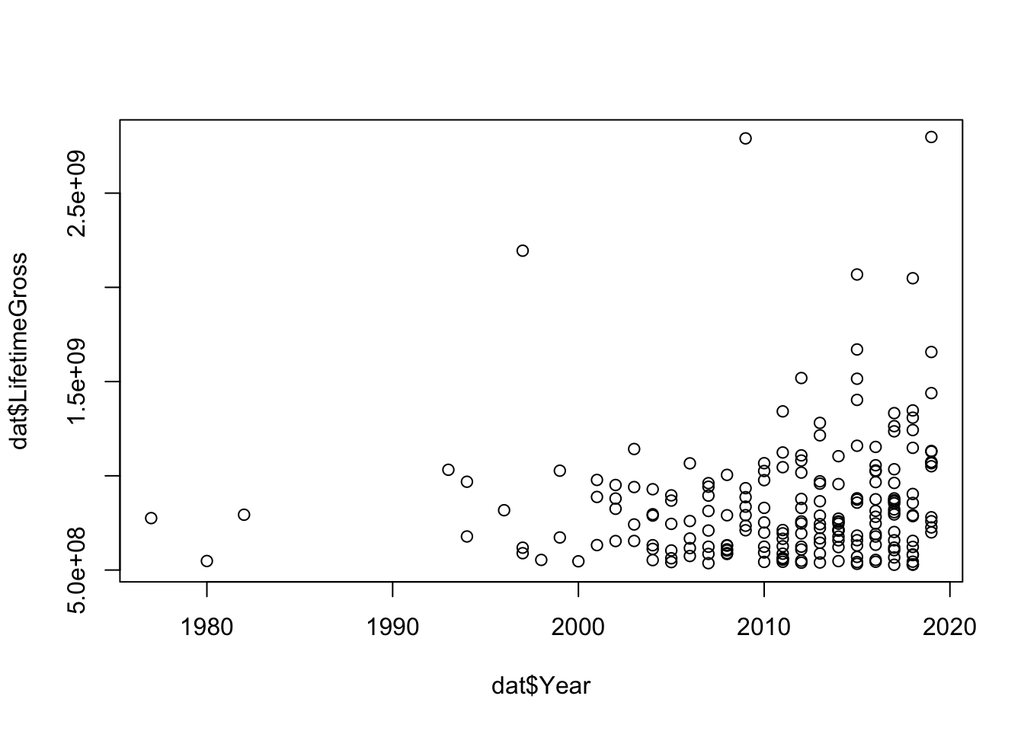

```r
plot(dat$Year, dat$LifetimeGross)
```

```r
# your answers here
```

**your explanations here** There seems to be a positive correlation between the Lifetime Gross of a move and the Year it came out. As the Year increases, the Lifetime gross of the movie also tends increases. The data is skewed to the left, meaning that there is more data on the right side of the graph.